# Are YouTube Ads Actually Targeted?

Levin Sherin

## What’s going on with this data?

YouTube often shows ads before, during, or after videos. These ads are meant to be targeted, but from a viewer’s perspective it is not always clear whether the ads actually match the video being watched.

For this project, I collected observational logging data about YouTube ads. Each row in my data represents one ad observation. I recorded the length of the ad, the device used, the video category, the ad category, whether the ad was interesting, and how related the ad seemed to the video.

The main question for this visual data story is:  
**Do YouTube ads seem meaningfully connected to the videos they appear on, and does that make them more interesting?**

## YouTube ad categories were scattered across many video topics

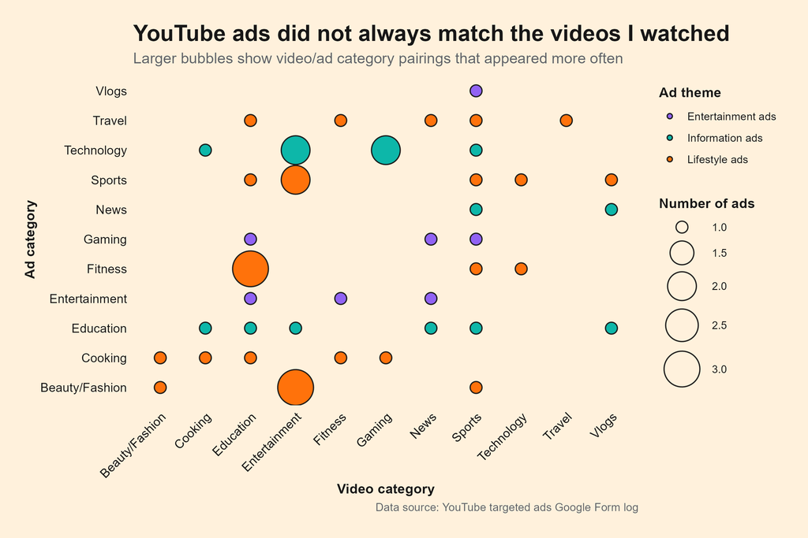

The first visualisation compares the category of the video being watched with the category of the ad that appeared. Each circle represents a video category and ad category pairing. Bigger circles show combinations that happened more often.

This plot suggests that YouTube ads were not always directly matched to the video category. Some ad categories appeared across several different video topics, which suggests that ad targeting may not only be based on the current video. It could also be influenced by broader user behaviour, advertiser targeting, or which ads were available at the time.

The key point is that the ads were spread across many different video topics, rather than always matching the video category exactly.

## Related ads were more likely to be interesting

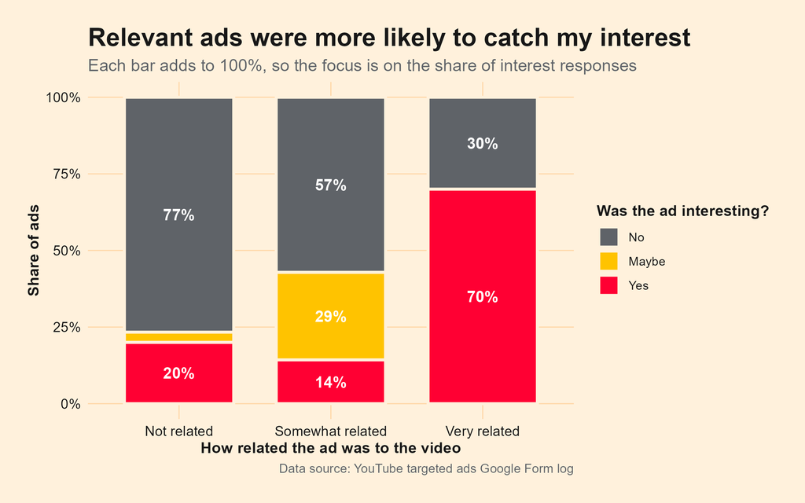

Stacked proportional bar chart showing how interest responses changed depending on whether ads were not related, somewhat related, or very related to the video. Each bar adds to 100 percent.

The second visualisation focuses on whether related ads were more likely to be interesting. Instead of using raw counts, I used proportions so that each relatedness group could be compared more fairly.

This plot shows the share of ads that were rated as “No”, “Maybe”, or “Yes” for interest within each relatedness level. This helps show whether the pattern of interest changes as ads become more related to the video.

The visualisation suggests that ads that were more related to the video were more likely to be interesting. This makes sense because an ad that connects to the video topic may feel more relevant to the viewer.

The key point is that relatedness appears to matter. Ads that felt more connected to the video were more likely to be viewed as interesting.

## The mix of ad themes changed across the day

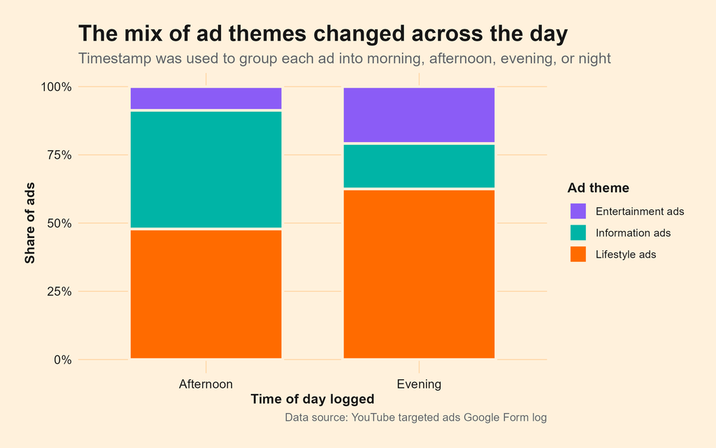

The third visualisation uses the timestamp from the Google Form data. I converted the timestamp into a date-time variable, then used it to group each ad observation into morning, afternoon, evening, or night.

This plot compares the types of ads that appeared during different parts of the day. Each bar adds to 100%, so the focus is not on the total number of ads, but on the mix of ad themes within each time period.

This is useful because ad targeting might not only depend on the video category. It may also be connected to when someone is watching, what kind of content is usually watched at that time, or what advertisers are targeting during different parts of the day.

The key point is that the mix of ad themes was not identical across the day. This suggests that YouTube advertising can feel inconsistent from a viewer’s perspective, because the ad shown may depend on more than just the video being watched.

## So, are YouTube ads actually targeted?

Overall, my visual data story suggests that YouTube ads do seem targeted in some ways, but not always in a simple or obvious way. The first visualisation showed that ad categories did not always directly match the categories of the videos being watched. This suggests that the current video topic is probably not the only factor involved.

However, the second visualisation showed that ads which felt more related to the video were also more likely to be interesting. This suggests that when ad targeting feels relevant, it can make the ad more effective from the viewer’s perspective.

The third visualisation added another layer by showing that the mix of ad themes changed across different times of day. This made the story more complex, because it suggests that ad targeting may be influenced by timing as well as video content.

A limitation of this data is that it is based on my own observations, so it cannot prove exactly how YouTube’s advertising algorithm works. However, it does show what targeted advertising can feel like from a viewer’s perspective. Some ads seemed connected and useful, while others felt more random. Because of this, my conclusion is that YouTube ads are targeted, but the targeting is not always obvious just from looking at the video the ad appears on.

## What this visual story shows

Overall, my visual data story suggests that YouTube ad targeting is mixed. The ads were not always directly matched to the video category, but ads that felt more related to the video were more likely to be interesting.

The strongest pattern in my data was the connection between relatedness and interest. This suggests that even if YouTube ads do not always match the exact video topic, viewers may respond more positively when the ad feels relevant to what they are watching.

## Limitations

There are some limitations to this data. Firstly, the data was collected through observational logging, so it only reflects the ads that appeared during my own observations. It may not represent all YouTube ads or all viewers.

Secondly, some variables involved personal judgement. For example, deciding whether an ad was “Somewhat related” or “Very related” depends on how I interpreted the connection between the ad and the video. Another person might classify some ads differently.

Finally, the sample size is limited. With more observations across more days, devices, and video types, the patterns would be more reliable.

## Conclusion

This project helped me turn observational data into a visual story. By cleaning the data, creating new variables, grouping categories, and using different ggplot visualisations, I was able to explore how YouTube ads appeared in relation to video content, interest, ad themes, and time of day. The main conclusion is that YouTube ads in my data were not always directly matched to the videos being watched, but ads that felt more related were more likely to be interesting. This shows that relevance is an important part of whether targeted advertising feels useful or random to a viewer.